# Session 14 - Creating Maps II

Fabian Gülzau

31 Januar 2018

## Programm

1. Recap: ggmap
2. Shapefiles und ggmap
3. Das Paket “sp” und Shapefiles in R
4. Shapefiles visualisieren mit tmap

## Pakete für die heutige Sitzung

Setup der heutigen Sitzung:

```r
library(tidyverse)
library(ggmap)
library(rgdal)
library(tmap)
library(rvest) # for scraping
```

Installation über `install.packages("tmap")` oder - alternativ - `devtools::install_github("mtennekes/tmap")`.

## Recap: ggmap

**Ziel**: Deutschlandkarte mit Bundeslandinformationen (Shapefile)

**Weg**:

1. ggmap und fortify
- 1. Karte herunterladen (`get_map()`)
- 2. Karte als Kontextlayer in ggplot2 verwenden (`ggmap()`)
- 3. Weitere Layer über ggplot2 ergänzen (etwa `geom_point`)
2. tmap und sp

## (1) Karte herunterladen

Zunächst benötigen wir eine Karte, die Deutschland abbildet.

```r
germany <- get_map(location = "Germany",
                   zoom = 6,
                   maptype = "toner",
                   source = "stamen")
```

Die Karte ist zunächst ein Bild, welches wir noch nicht verwenden können:

```r
str(germany, max.level = 2)
```

```
##  'ggmap' chr [1:639, 1:639] "#000000" "#000000" "#000000" "#000000" ...
##  - attr(*, "bb")='data.frame':   1 obs. of  4 variables:
##   ..$ ll.lat: num 46.5
##   ..$ ll.lon: num 3.43
##   ..$ ur.lat: num 55.4
##   ..$ ur.lon: num 17.5
##  - attr(*, "source")= chr "stamen"
##  - attr(*, "maptype")= chr "toner"
##  - attr(*, "zoom")= num 6
```

## (2) Die Karte als Layer

Um die Karte verwenden zu können, definieren wir diese als Layer für ggplot2. Dies erfolgt mit der Funktion `ggmap`:

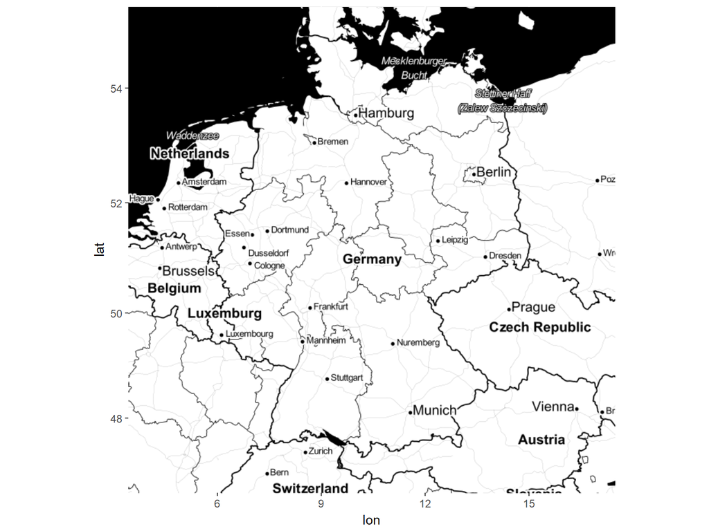

```r
ger.map <- ggmap(germany)
ger.map
```

## (3) Weitere Layer ergänzen: Daten I

Um einige Daten zur Visualisierung verfügbar zu machen, scrapen wir eine Tabelle von Wikipedia (Tabelle “Politik”).

```r
# Scrapen
city <- read_html("https://de.wikipedia.org/wiki/Land_(Deutschland)") %>%
  html_nodes(css = "table.wikitable:nth-child(22)") %>%
  html_table() %>%
  .[[1]] %>%
  .[-17,-1]

# Stadtnamen ergänzen
city[c(3, 5, 6), "Hauptstadt"] <- c("Berlin", "Bremen", "Hamburg")

# Daten in numerische Werte umwandeln
city.df <- city %>%
  mutate_at(vars(`Ein-wohner(Mio.)[12]`,`Ausländer(%)[13]` ),
            .funs = funs(as.numeric(stringr::str_replace_all(string = ., pattern = ",", replacement = "\\."))))

# Variablennamen
colnames(city.df) <- c("Land", "Kürzel", "Hauptstadt", "Beitritt", "Regierung", "Parteien",
                       "Stimmen", "Fläche", "Einwohner", "EinwDichte", "Ausländeranteil", "Sprachen")
```

```r
glimpse(city.df)
```

[output not shown]

## (3) Weitere Layer ergänzen: Daten II

Um den Datensatz “spatial” zu machen, geokodieren wir die Landeshauptstädte mit Hilfe von ggmap. Hierfür steht uns die Funktion `geocode` zur Verfügung.

An einem einzelnen Fall:

```r
# General logic for geocoding
geocode(location = "Stuttgart", output = "latlon", source = "google", inject = ", Germany")
```

Für alle Landeshauptstädte (loop mit Bedingung, da google oft zickig ist):

```r
# Um nicht über das query limit zu kommen, nehmt lieber den Datensatz aus dem Kurs

# Wrap into a loop
# Create variables beforehand
city.df$lon <- NA
city.df$lat <- NA

# for loop with if-condition for warnings
# run several times until no more NA's are returned
for(i in 1:nrow(city.df)) {
  if (is.na(city.df$lon[i])) {
    result <- tryCatch(geocode(city.df$Hauptstadt[i], output = "latlon", source = "google", inject = ", Germany"),
                       warning = function(x) data.frame(lon = NA, lat = NA))
    city.df$lon[i] <- as.numeric(result[1])
    city.df$lat[i] <- as.numeric(result[2])
  }
  i <- i + 1
  Sys.sleep(sample(seq(.5, 2, 0.5), 1))
}
```

Das Ergebnis:

```
## Observations: 16
## Variables: 3
## $ Hauptstadt <chr> "Stuttgart", "München", "Berlin", "Potsdam", "Breme...
## $ lat        <dbl> 48.77585, 48.13513, 52.52001, 52.39057, 53.07930, 5...
## $ lon        <dbl> 9.182932, 11.581981, 13.404950, 13.064473, 8.801694...
```

## (3) Weitere Layer ergänzen

Nun können wir mit der gewöhnlichen ggplot2-Logik weitere Layer ergänzen

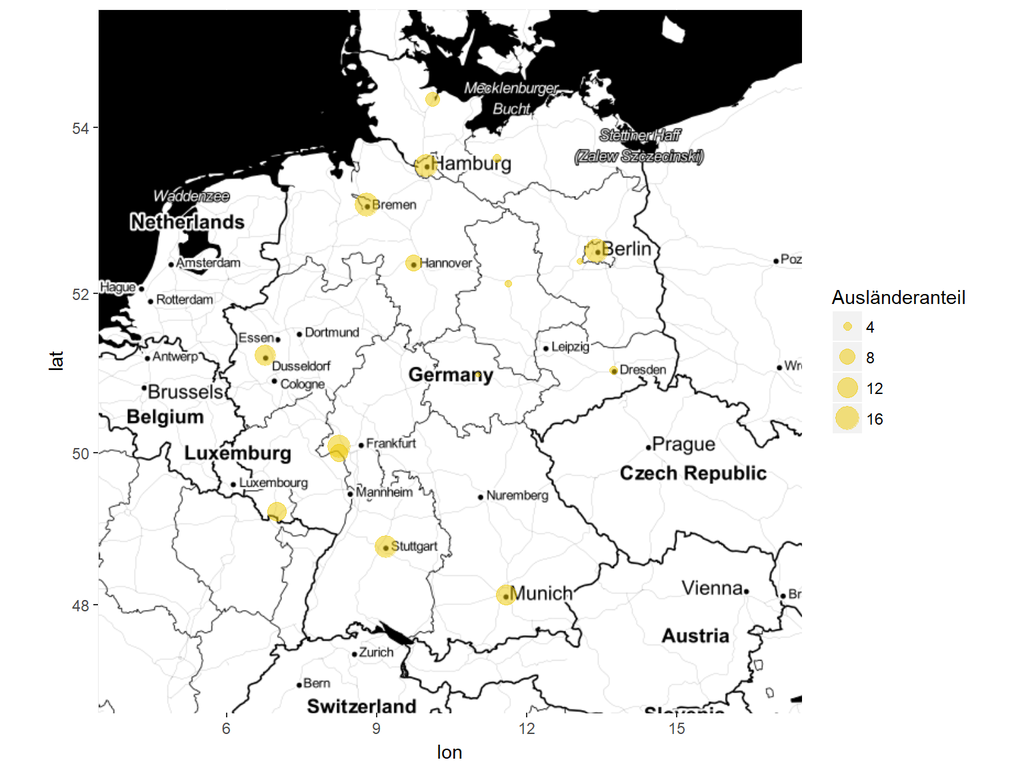

```r
# Doesn't look good but serves the purposes
ger.map +
  geom_point(data = city.df, mapping = aes(x = lon, y = lat, size = Ausländeranteil), color = "gold2", alpha = .5)
```

## Shapefiles und ggmap

Wir hatten in der letzten Sitzung bereits gesehen, dass sich die ggmap-Karten auch mit Shapefiles kombinieren lassen:

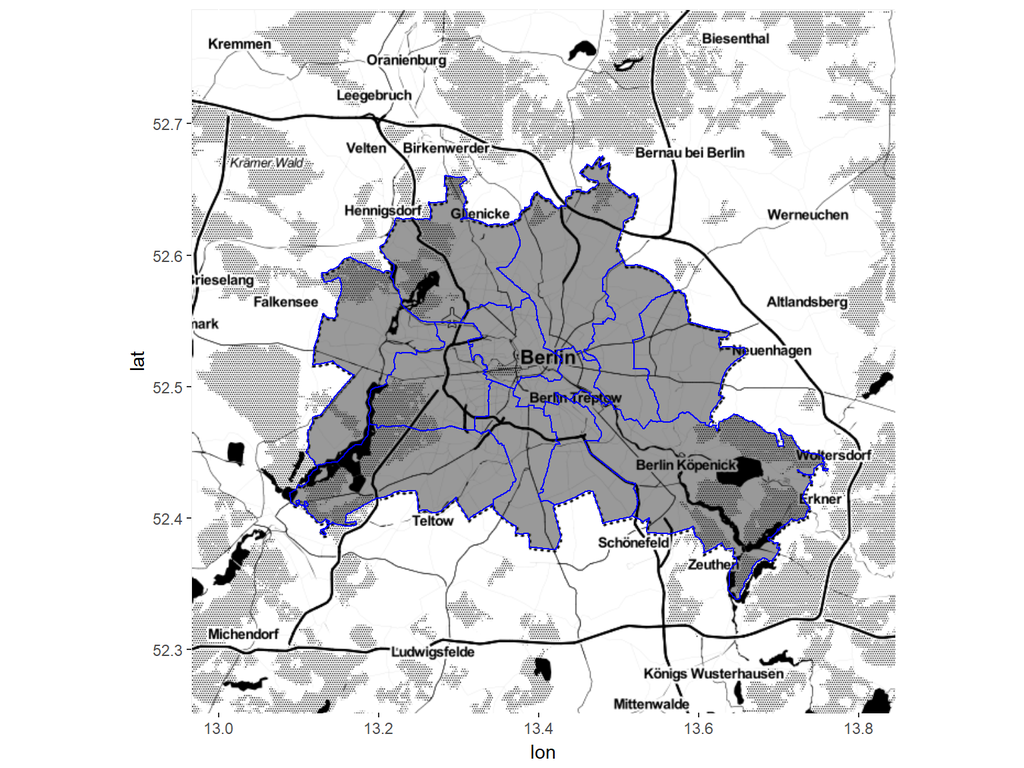

## Shapefiles und ggmap

Dies wollen wir nun mit einem Shapefile, welches die Bundesländer Deutschlands enthält ([Quelle](http://opendata-esri-de.opendata.arcgis.com/datasets/vg250-bundesl%C3%A4ndergrenzen-2017) / [Weitere Informationen](http://sg.geodatenzentrum.de/web_download/vg/vg250_0101/vg250_0101.pdf)), wiederholen.

Das Vorgehen für ggmap:

1. Shapefile laden (`readOGR`)
2. Shapefile in einen Data Frame umwandeln (`ggfortify`)

```r
# Hier wird das Paket rdgdal benötigt
# (1) Shapefile laden
bl.shp <- readOGR(dsn = "C:/Users/User/HU-Box/Seafile/Meine Bibliothek/Seminare/WS 2017/Sessions/Session 14/VG250_BL",
                  use_iconv = TRUE, encoding = "UTF-8", stringsAsFactors = FALSE)
# Zwei Bundesländer umbennen (für später)
bl.shp@data$GEN[bl.shp@data$GEN == "Baden-Württemberg (Bodensee)"] <- "Baden-Württemberg"
bl.shp@data$GEN[bl.shp@data$GEN == "Bayern (Bodensee)"] <- "Bayern"

# (2) ggfortify
bl.for <- fortify(bl.shp)
glimpse(bl.for)
```

```
## Observations: 214,390
## Variables: 7
## $ long  <dbl> 8.449215, 8.451194, 8.453338, 8.455876, 8.457736, 8.4594...
## $ lat   <dbl> 55.04958, 55.04907, 55.04859, 55.04805, 55.04770, 55.047...
## $ order <int> 1, 2, 3, 4, 5, 6, 7, 8, 9, 10, 11, 12, 13, 14, 15, 16, 1...
## $ hole  <lgl> FALSE, FALSE, FALSE, FALSE, FALSE, FALSE, FALSE, FALSE, ...
## $ piece <fctr> 1, 1, 1, 1, 1, 1, 1, 1, 1, 1, 1, 1, 1, 1, 1, 1, 1, 1, 1...
## $ id    <chr> "0", "0", "0", "0", "0", "0", "0", "0", "0", "0", "0", "...
## $ group <fctr> 0.1, 0.1, 0.1, 0.1, 0.1, 0.1, 0.1, 0.1, 0.1, 0.1, 0.1, ...
```

## Shapefiles und ggmap

Nun nehmen wir, wie in der letzten Woche, den ggmap-layer und ergänzen ihn um das `geom_polygon`:

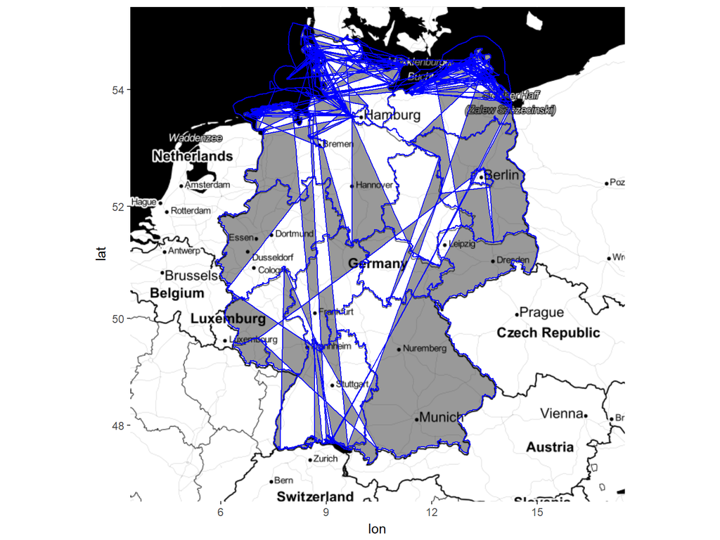

```r
ger.map +
  geom_polygon(data = bl.for, mapping = aes(x = long, y = lat, fill = id),
               color = "blue", fill = "black", alpha = .4)
```

Ups! Dies sieht mal wieder eher nach [accidental aRt](http://accidental-art.tumblr.com/) aus… Was ist schief gelaufen?

## Das Paket “sp” und Shapefiles in R

Es scheint als müssten wir uns doch stärker mit Shapefiles und der zugrundeliegenden Implementierung im Paket “sp” beschäftigen.

Typ und Klassen von Shapefiles in R:

```r
typeof(bl.shp)
```

```
## [1] "S4"
```

```r
class(bl.shp)
```

```
## [1] "SpatialPolygonsDataFrame"
## attr(,"package")
## [1] "sp"
```

Hello, who’s in there?

```r
str(bl.shp, max.level = 2) # useful args: max.level & list.len
```

```
## Formal class 'SpatialPolygonsDataFrame' [package "sp"] with 5 slots
##   ..@ data       :'data.frame':  35 obs. of  26 variables:
##   ..@ polygons   :List of 35
##   ..@ plotOrder  : int [1:35] 9 3 5 8 12 13 15 6 7 14 ...
##   ..@ bbox       : num [1:2, 1:2] 5.87 47.27 15.04 55.1
##   .. ..- attr(*, "dimnames")=List of 2
##   ..@ proj4string:Formal class 'CRS' [package "sp"] with 1 slot
```

Fünf “Slots” - tauchen wir noch tiefer ein:

```r
str(bl.shp@data, max.level = 2, list.len = 3)
```

```
## 'data.frame':    35 obs. of  26 variables:
##  $ OBJECTID  : chr  "1" "2" "3" "4" ...
##  $ ADE       : chr  "2" "2" "2" "2" ...
##  $ GF        : chr  "4" "4" "4" "4" ...
##   [list output truncated]
```

```r
str(bl.shp@polygons, max.level = 2, list.len = 3)
```

```
## List of 35
##  $ :Formal class 'Polygons' [package "sp"] with 5 slots
##  $ :Formal class 'Polygons' [package "sp"] with 5 slots
##  $ :Formal class 'Polygons' [package "sp"] with 5 slots
##   [list output truncated]
```

```r
str(bl.shp@plotOrder)
```

```
##  int [1:35] 9 3 5 8 12 13 15 6 7 14 ...
```

```r
str(bl.shp@bbox)
```

```
##  num [1:2, 1:2] 5.87 47.27 15.04 55.1
##  - attr(*, "dimnames")=List of 2
##   ..$ : chr [1:2] "x" "y"
##   ..$ : chr [1:2] "min" "max"
```

```r
str(bl.shp@proj4string) # http://proj4.org/projections/index.html
```

```
## Formal class 'CRS' [package "sp"] with 1 slot
##   ..@ projargs: chr "+proj=longlat +datum=WGS84 +no_defs +ellps=WGS84 +towgs84=0,0,0"
```

Eine gute Möglichkeit rekursive Listen oder S4-Klassen zu untersuchen ist das Widget “listviewer”:

```r
# Es dauert recht lange bis die Struktur geladen ist, weshalb es hier nicht gezeigt wird.
listviewer::jsonedit(bl.shp)
```

## 4. Shapefiles visualisieren mit tmap

Um shapefiles in R zu plotten, lässt sich entweder base-R verwenden (`plot(bl.shp)`) oder das [Paket](https://cran.r-project.org/web/packages/tmap/vignettes/tmap-nutshell.html) `tmap` heranziehen, welches sich an ggplot2 orientiert:

1. Karte initiieren (`tm_shape`)
2. Base layer (z.B. `tm_polygon`)
3. Weitere Layer hinzufügen
- `tm_fill` (füllt nach Variablen)
- `tm_dots` (wie geom_point)
- `tm_borders` (die Ansicht der Grenzen beschreiben)
3. Layout setzen (`tm_layout`)

## Ein erster Plot mit tmap

Wir verwenden das Shapefile bl.shp, um tmap kennenzulernen:

```r
tm_shape(shp = bl.shp) +
  tm_polygons()
```

[output not shown]

## Weitere Daten verwenden

Mergen:

1. Ursprüngliches Shapefile und zusätzliche Daten benötigen einen “identifier”
2. Mergen über `merge()`

```r
bl.shp <- sp::merge(bl.shp, city.df, by.x = "GEN", by.y = "Land")

# Auch Seegebiete entfernen (indexing)
bl.shp <- bl.shp[bl.shp@data$GF != 1,]
```

## tmap mit zusätzlichen Daten

Wir können nun den layer `tm_polygons` mit unseren zusätzlichen Daten anreichern. Probiert dies mal aus (`?tm_polygons` oder `tm_fill`). Wichtig ist, dass Variablen in Anführungszeichen übergeben werden (`"var"`).

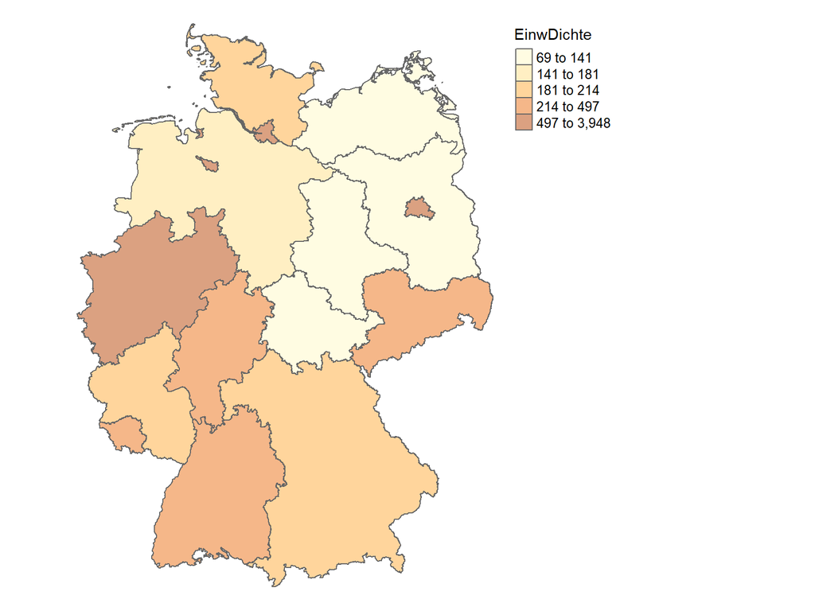

## Weitere Informationen zu Spatial Data in R

Folgende Ressourcen stehen zur Verfügung, um sich in das Thema zu vertiefen:

- tmap ([Workshop](https://data.cdrc.ac.uk/dataset/an-introduction-to-spatial-data-analysis-and-visualisation-in-r) / [GitHub](https://github.com/mtennekes/tmap))
- [Bivand et al. (2013)](http://www.springer.com/de/book/9781461476177)
- Übersicht auf [CRAN](https://cran.r-project.org/web/views/Spatial.html)
- [weitere Pakete](https://github.com/ropensci/maptools) mit enthaltenen Shapefiles (maptools etc.)

## Europakarten

tmap stellt Daten zu Europa zur Verfügung. Könnt ihr damit Karten erstellen?

```r
data(Europe)
```